## HEADER

Who:KK

What: logistic algoritham

Last edited: 2023-04-08

## CONTENTS

introduction

Logistic Regression

## Introduction

The dataset we are taking is inbuild in R and its about stock market. Weekly percentage returns for the S&P 500 stock index between 1990 and 2010. A data frame with 1089 observations on the following 9 variables.

# Year

The year that the observation was recorded.

# Lag1

Percentage return for previous week.

# Lag2

Percentage return for 2 weeks previous

# Lag3

Percentage return for 3 weeks previous

# Lag4

Percentage return for 4 weeks previous

# Lag5

Percentage return for 5 weeks previous

# Volume

Volume of shares traded (average number of daily shares traded in billions)

# Today

Percentage return for this week

# Direction

A factor with levels Down and Up indicating whether the market had a positive or negative return on a given week.

# Problem statement

we have to predict the market whether it goes up or down based on the certain features provided.

# load the dataset

```r
library(ISLR)
data(Weekly)
str(Weekly)
```

```
## 'data.frame':    1089 obs. of  9 variables:
##  $ Year     : num  1990 1990 1990 1990 1990 1990 1990 1990 1990 1990 ...
##  $ Lag1     : num  0.816 -0.27 -2.576 3.514 0.712 ...
##  $ Lag2     : num  1.572 0.816 -0.27 -2.576 3.514 ...
##  $ Lag3     : num  -3.936 1.572 0.816 -0.27 -2.576 ...
##  $ Lag4     : num  -0.229 -3.936 1.572 0.816 -0.27 ...
##  $ Lag5     : num  -3.484 -0.229 -3.936 1.572 0.816 ...
##  $ Volume   : num  0.155 0.149 0.16 0.162 0.154 ...
##  $ Today    : num  -0.27 -2.576 3.514 0.712 1.178 ...
##  $ Direction: Factor w/ 2 levels "Down","Up": 1 1 2 2 2 1 2 2 2 1 ...
```

```r
summary(Weekly)
```

```
##       Year           Lag1               Lag2               Lag3
##  Min.   :1990   Min.   :-18.1950   Min.   :-18.1950   Min.   :-18.1950
##  1st Qu.:1995   1st Qu.: -1.1540   1st Qu.: -1.1540   1st Qu.: -1.1580
##  Median :2000   Median :  0.2410   Median :  0.2410   Median :  0.2410
##  Mean   :2000   Mean   :  0.1506   Mean   :  0.1511   Mean   :  0.1472
##  3rd Qu.:2005   3rd Qu.:  1.4050   3rd Qu.:  1.4090   3rd Qu.:  1.4090
##  Max.   :2010   Max.   : 12.0260   Max.   : 12.0260   Max.   : 12.0260
##       Lag4               Lag5              Volume            Today
##  Min.   :-18.1950   Min.   :-18.1950   Min.   :0.08747   Min.   :-18.1950
##  1st Qu.: -1.1580   1st Qu.: -1.1660   1st Qu.:0.33202   1st Qu.: -1.1540
##  Median :  0.2380   Median :  0.2340   Median :1.00268   Median :  0.2410
##  Mean   :  0.1458   Mean   :  0.1399   Mean   :1.57462   Mean   :  0.1499
##  3rd Qu.:  1.4090   3rd Qu.:  1.4050   3rd Qu.:2.05373   3rd Qu.:  1.4050
##  Max.   : 12.0260   Max.   : 12.0260   Max.   :9.32821   Max.   : 12.0260
##  Direction
##  Down:484
##  Up  :605
##
##
##
##
```

# To check the missing values

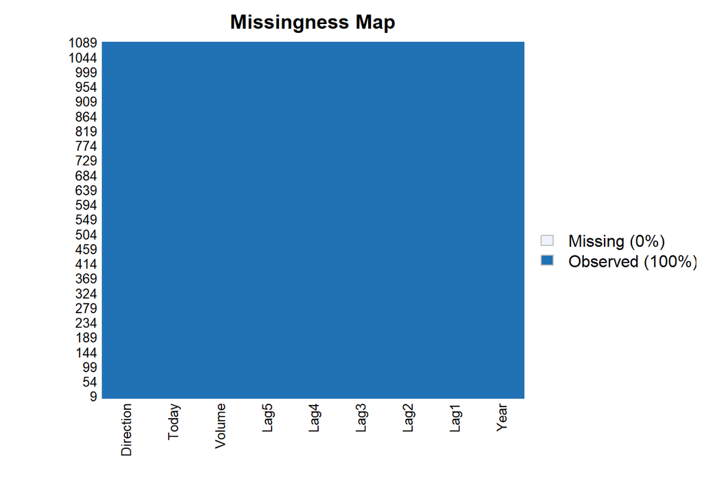

```r
library(Amelia)
missmap(Weekly)
```

```r
dim(Weekly)
```

```
## [1] 1089    9
```

# Exlude the year and volume column

```r
data <- subset(Weekly, select = c(2,3,4,5,6,8,9))
data
```

[output not shown]

[output cut: 1075 more lines]

I have excluded year and volumn column because of multicolinearity(Highly correlated) it will leading to unreliable and unstable estimates of regression coefficients. it is performed using the function vif(if the value is more than 5 we should exclude the values)

## Logistic Regression

Logistic Regression is merely regression where the dependent variable is binary (up, down; yes, no; 0, 1; etc.).

# split the data into train and test

```r
library(caTools) #library for test and training
set.seed(1)
sample_log <- sample.split(data$Direction, SplitRatio = 0.7)
sample_log
```

[output not shown]

[output cut: 76 more lines]

```r
train <- subset(data,sample_log == TRUE)
test <- subset(data, sample_log == FALSE)
```

# Deploy the logistic model

```r
set.seed(123)
glm_stock <- glm(Direction ~ ., data = train, family = "binomial")
glm_stock
```

```
##
## Call:  glm(formula = Direction ~ ., family = "binomial", data = train)
##
## Coefficients:
## (Intercept)         Lag1         Lag2         Lag3         Lag4         Lag5
##     -2.4579      -5.4705       0.5795       1.1689       2.6668       6.4162
##       Today
##    495.3815
##
## Degrees of Freedom: 762 Total (i.e. Null);  756 Residual
## Null Deviance:       1048
## Residual Deviance: 3.087e-06     AIC: 14
```

#Check the multicolinearity

```r
library(car)
vif_values <- vif(glm_stock)
vif_values
```

```
##     Lag1     Lag2     Lag3     Lag4     Lag5    Today
## 3.178980 2.417517 2.157560 1.718107 2.271553 1.236545
```

#summary

```r
summary(glm_stock)
```

```
##
## Call:
## glm(formula = Direction ~ ., family = "binomial", data = train)
##
## Deviance Residuals:
##        Min          1Q      Median          3Q         Max
## -7.351e-04  -2.000e-08   2.000e-08   2.000e-08   9.275e-04
##
## Coefficients:
##               Estimate Std. Error z value Pr(>|z|)
## (Intercept)    -2.4579   788.9955  -0.003    0.998
## Lag1           -5.4705   471.8961  -0.012    0.991
## Lag2            0.5795   651.6649   0.001    0.999
## Lag3            1.1689   644.6809   0.002    0.999
## Lag4            2.6668   387.8416   0.007    0.995
## Lag5            6.4162   758.0335   0.008    0.993
## Today         495.3815 15765.6428   0.031    0.975
##
## (Dispersion parameter for binomial family taken to be 1)
##
##     Null deviance: 1.0483e+03  on 762  degrees of freedom
## Residual deviance: 3.0868e-06  on 756  degrees of freedom
## AIC: 14
##
## Number of Fisher Scoring iterations: 25
```

# Result

# Problem Statement

To study a Diabetes data set and build a Machine Learning model that predicts whether or not a person has Diabetes.

# About the dataset

pregnant Number of times pregnant

glucose Plasma glucose concentration (glucose tolerance test)

triceps Triceps skin fold thickness (mm)

insulin 2-Hour serum insulin (mu U/ml)

mass Body mass index (weight in kg/(height in m)^2)

pedigree Diabetes pedigree function

age Age (years)

diabetes Class variable (test for diabetes)

# load library

```r
library(mlbench)
data(PimaIndiansDiabetes)
levels(PimaIndiansDiabetes$diabetes)
```

```
## [1] "neg" "pos"
```

```r
PimaIndiansDiabetes$diabetes <- ifelse(PimaIndiansDiabetes$diabetes == "pos",1,0)
```

make postive 1 and negative 0

# Check the missing values

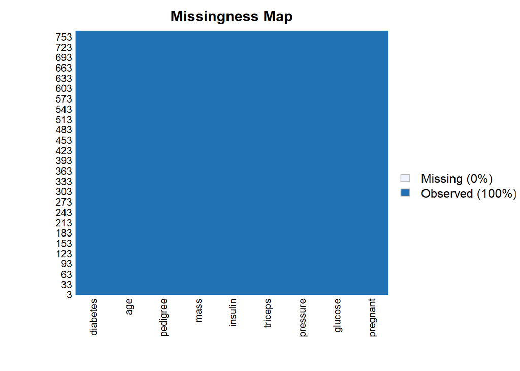

```r
library(Amelia)
missmap(PimaIndiansDiabetes)
```

# Split the dataset into train and test

```r
set.seed(1)
sample <- sample.split(PimaIndiansDiabetes$diabetes, SplitRatio = 0.7)
train_data <-subset(PimaIndiansDiabetes, sample == TRUE)
test_data <-subset(PimaIndiansDiabetes, sample == FALSE)
```

# Deploy the glm()

```r
result <- glm(diabetes ~ ., data = train_data, family = "binomial")
summary(result)
```

```
##
## Call:
## glm(formula = diabetes ~ ., family = "binomial", data = train_data)
##
## Deviance Residuals:
##     Min       1Q   Median       3Q      Max
## -2.6692  -0.6989  -0.3957   0.6778   3.1059
##
## Coefficients:
##               Estimate Std. Error z value Pr(>|z|)
## (Intercept) -8.8674112  0.9082424  -9.763  < 2e-16 ***
## pregnant     0.0998500  0.0389323   2.565  0.01033 *
## glucose      0.0370864  0.0044224   8.386  < 2e-16 ***
## pressure    -0.0121143  0.0061716  -1.963  0.04966 *
## triceps     -0.0092675  0.0084546  -1.096  0.27301
## insulin      0.0004008  0.0011124   0.360  0.71865
## mass         0.0976570  0.0186232   5.244 1.57e-07 ***
## pedigree     1.1329183  0.3712654   3.052  0.00228 **
## age          0.0114250  0.0115404   0.990  0.32217
## ---
## Signif. codes:  0 '***' 0.001 '**' 0.01 '*' 0.05 '.' 0.1 ' ' 1
##
## (Dispersion parameter for binomial family taken to be 1)
##
##     Null deviance: 696.28  on 537  degrees of freedom
## Residual deviance: 488.41  on 529  degrees of freedom
## AIC: 506.41
##
## Number of Fisher Scoring iterations: 5
```

# Checking importance of the each variable of the model

```r
library(caret)
x <- varImp(result)
x
```

```
##            Overall
## pregnant 2.5647063
## glucose  8.3859569
## pressure 1.9628986
## triceps  1.0961472
## insulin  0.3602590
## mass     5.2438272
## pedigree 3.0515052
## age      0.9900029
```

# Check for multicolineraty

```r
vif(result)
```

```
## pregnant  glucose pressure  triceps  insulin     mass pedigree      age
## 1.449596 1.134378 1.133955 1.554324 1.374398 1.192159 1.029482 1.525518
```

#predict the model

```r
predict_model <- predict(result, test_data, type = "response")
```

# Evaluate the model

```r
threshold <- 0.5
```

The threshold variable is set to 0.5, which is the default threshold for logistic regression models.

```r
predicted <- ifelse(predict_model > threshold, 1,0)
cm <- table(predicted, test_data$diabetes)
cm
```

```
##
## predicted   0   1
##         0 134  40
##         1  16  40
```

```r
library(pROC)
roc <- auc(test_data$diabetes, predicted)
roc
```

```
## Area under the curve: 0.6967
```

# Calculate accuracy, precision, and F1 score

```r
accuracy <- mean(test_data$diabetes == predicted)
precision <- sum(test_data$diabetes & predicted) / sum(predicted)
recall <- sum(test_data$diabetes & predicted) / sum(test_data$diabetes)
f1_score <- 2 * (precision * recall) / (precision + recall)
```

# Print the results

```r
cat(paste0("Accuracy: ", round(accuracy, 2), "\n"))
```

```
## Accuracy: 0.76
```

```r
cat(paste0("Precision: ", round(precision, 2), "\n"))
```

```
## Precision: 0.71
```

```r
cat(paste0("F1 Score: ", round(f1_score, 2), "\n"))
```

```
## F1 Score: 0.59
```

```r
cat(paste0("recall: ", round(recall, 2), "\n"))
```

```
## recall: 0.5
```

# Result

Area under the curve measured between 0 to 1. whic is used to check the accuracy of the model in our case the value is 0.69 which is a moderate performace for prediciting whether patient have a diabetes or not.the value must be close to one.

confusion matrix is also used to check the accuracy of the model in our case the accuracy is 0.76 not bad.precision refers to the quality of positive predictions 0.71 which is also not bad.so overall the model performed average. so we need to change the algoritham for this model.